# Destination shares within earmarked revenue classes

IMF research project

2026-08-25

This notebook adds share-based heatmaps to the country-focus analysis without changing the existing Sankeys, count heatmaps, or their plot-data files. It uses the completed count grids produced by the partial/exclusive earmark workflow. Within every country and revenue class, destination shares use the total number of statutory allocation links originating from that revenue class as the denominator.

The underlying database is a **de jure** legal inventory. These figures do not measure collections, transfers, disbursements, or expenditure execution.

# 1. Validate the existing count grids

The four inputs are the exact completed count grids behind the existing country-focus heatmaps. They already reflect the partial/exclusive earmark filter and the established allocation-link unit. Reading these grids directly keeps the prior analytical workflow and all existing outputs unchanged.

```r
if (!all(file.exists(count_grid_paths))) {
  missing_paths <- count_grid_paths[!file.exists(count_grid_paths)]
  stop(
    "Required count-grid inputs are missing: ",
    paste(missing_paths, collapse = "; ")
  )
}

input_md5_before <- unname(tools::md5sum(count_grid_paths))

required_columns <- c(
  "country",
  "country_name",
  "destination_level",
  "revenue_class",
  "revenue_class_label",
  "source_plot_label",
  "source_order",
  "source_total_links",
  "destination_code",
  "destination_name",
  "destination_label",
  "destination_plot_label",
  "destination_order",
  "destination_total_links",
  "destination_mapping_status",
  "n_atomic_links",
  "destination_heatmap_label",
  "cell_label"
)

count_grids <- imap(
  count_grid_paths,
  ~read_csv(
    .x,
    show_col_types = FALSE,
    progress = FALSE
  )
)

schema_audit <- imap_dfr(count_grids, function(data, input_name) {
  tibble(
    input_name,
    rows = nrow(data),
    missing_columns = paste(
      setdiff(required_columns, names(data)),
      collapse = "; "
    ),
    additional_columns = paste(
      setdiff(names(data), required_columns),
      collapse = "; "
    )
  )
})

if (any(schema_audit$missing_columns != "")) {
  print(schema_audit)
  stop("A required count-grid column is missing.")
}

identity_audit <- imap_dfr(count_grids, function(data, input_name) {
  expected <- expected_inputs %>% filter(.data$input_name == .env$input_name)

  tibble(
    input_name,
    expected_country = expected$expected_country,
    observed_countries = paste(sort(unique(data$country)), collapse = "; "),
    expected_destination_level = expected$expected_destination_level,
    observed_destination_levels = paste(
      sort(unique(data$destination_level)),
      collapse = "; "
    ),
    country_passed = identical(
      sort(unique(data$country)),
      expected$expected_country
    ),
    destination_level_passed = identical(
      sort(unique(data$destination_level)),
      expected$expected_destination_level
    )
  )
})

if (!all(identity_audit$country_passed) ||
    !all(identity_audit$destination_level_passed)) {
  print(identity_audit)
  stop("A count grid does not match its expected country or destination level.")
}
```

```r
display_table(schema_audit)
```

```
##
##
## |input_name   | rows|missing_columns |additional_columns |
## |:------------|----:|:---------------|:------------------|
## |civ_cofog4   |  396|                |                   |
## |civ_division |  132|                |                   |
## |cmr_cofog4   |  132|                |                   |
## |cmr_division |   54|                |                   |
```

```r
display_table(identity_audit)
```

```
##
##
## |input_name   |expected_country |observed_countries |expected_destination_level |observed_destination_levels |country_passed |destination_level_passed |
## |:------------|:----------------|:------------------|:--------------------------|:---------------------------|:--------------|:------------------------|
## |civ_cofog4   |CIV              |CIV                |four_digit_function        |four_digit_function         |TRUE           |TRUE                     |
## |civ_division |CIV              |CIV                |division                   |division                    |TRUE           |TRUE                     |
## |cmr_cofog4   |CMR              |CMR                |four_digit_function        |four_digit_function         |TRUE           |TRUE                     |
## |cmr_division |CMR              |CMR                |division                   |division                    |TRUE           |TRUE                     |
```

```r
grid_key_audit <- imap_dfr(count_grids, function(data, input_name) {
  duplicate_keys <- data %>%
    count(country, revenue_class, destination_code, name = "n") %>%
    filter(n > 1L)

  tibble(
    input_name,
    rows = nrow(data),
    n_revenue_classes = n_distinct(data$revenue_class),
    n_destinations = n_distinct(data$destination_code),
    expected_complete_grid_rows =
      n_distinct(data$revenue_class) * n_distinct(data$destination_code),
    duplicate_grid_keys = nrow(duplicate_keys),
    missing_grid_keys = sum(
      is.na(data$country) |
        is.na(data$revenue_class) |
        is.na(data$destination_code)
    ),
    missing_link_counts = sum(is.na(data$n_atomic_links)),
    negative_link_counts = sum(data$n_atomic_links < 0, na.rm = TRUE)
  )
})

source_total_audit <- imap_dfr(count_grids, function(data, input_name) {
  data %>%
    group_by(
      country,
      revenue_class,
      revenue_class_label
    ) %>%
    summarise(
      stored_source_totals = n_distinct(source_total_links),
      stored_source_total = first(source_total_links),
      computed_source_total = sum(n_atomic_links),
      denominator_positive = computed_source_total > 0,
      stored_equals_computed =
        stored_source_totals == 1L &&
        stored_source_total == computed_source_total,
      .groups = "drop"
    ) %>%
    mutate(input_name = .env$input_name, .before = 1)
})

if (any(grid_key_audit$rows != grid_key_audit$expected_complete_grid_rows) ||
    any(grid_key_audit$duplicate_grid_keys > 0L) ||
    any(grid_key_audit$missing_grid_keys > 0L) ||
    any(grid_key_audit$missing_link_counts > 0L) ||
    any(grid_key_audit$negative_link_counts > 0L) ||
    any(!source_total_audit$denominator_positive) ||
    any(!source_total_audit$stored_equals_computed)) {
  print(grid_key_audit)
  print(source_total_audit %>% filter(!stored_equals_computed))
  stop("A count-grid key or source-denominator check failed.")
}
```

```r
display_table(grid_key_audit)
```

```
##
##
## |input_name   | rows| n_revenue_classes| n_destinations| expected_complete_grid_rows| duplicate_grid_keys| missing_grid_keys| missing_link_counts| negative_link_counts|
## |:------------|----:|-----------------:|--------------:|---------------------------:|-------------------:|-----------------:|-------------------:|--------------------:|
## |civ_cofog4   |  396|                12|             33|                         396|                   0|                 0|                   0|                    0|
## |civ_division |  132|                12|             11|                         132|                   0|                 0|                   0|                    0|
## |cmr_cofog4   |  132|                 6|             22|                         132|                   0|                 0|                   0|                    0|
## |cmr_division |   54|                 6|              9|                          54|                   0|                 0|                   0|                    0|
```

```r
display_table(source_total_audit)
```

```
##
##
## |input_name   |country |revenue_class                              |revenue_class_label                        | stored_source_totals| stored_source_total| computed_source_total|denominator_positive |stored_equals_computed |
## |:------------|:-------|:------------------------------------------|:------------------------------------------|--------------------:|-------------------:|---------------------:|:--------------------|:----------------------|
## |civ_cofog4   |CIV     |Missing                                    |Missing revenue classification             |                    1|                  81|                    81|TRUE                 |TRUE                   |
## |civ_cofog4   |CIV     |administrative_regulatory_and_user_charges |Administrative regulatory and user charges |                    1|                 125|                   125|TRUE                 |TRUE                   |
## |civ_cofog4   |CIV     |environmental_and_pollution                |Environmental and pollution                |                    1|                  12|                    12|TRUE                 |TRUE                   |
## |civ_cofog4   |CIV     |excises_and_specific_consumption           |Excises and specific consumption           |                    1|                  11|                    11|TRUE                 |TRUE                   |
## |civ_cofog4   |CIV     |general_consumption_and_turnover           |General consumption and turnover           |                    1|                   7|                     7|TRUE                 |TRUE                   |
## |civ_cofog4   |CIV     |income_profits_and_capital_gains           |Income profits and capital gains           |                    1|                   4|                     4|TRUE                 |TRUE                   |
## |civ_cofog4   |CIV     |international_trade_and_customs            |International trade and customs            |                    1|                   7|                     7|TRUE                 |TRUE                   |
## |civ_cofog4   |CIV     |natural_resources_and_extractives          |Natural resources and extractives          |                    1|                  36|                    36|TRUE                 |TRUE                   |
## |civ_cofog4   |CIV     |payroll_and_social_contributions           |Payroll and social contributions           |                    1|                   4|                     4|TRUE                 |TRUE                   |
## |civ_cofog4   |CIV     |penalties_interest_and_other_receipts      |Penalties interest and other receipts      |                    1|                   3|                     3|TRUE                 |TRUE                   |
## |civ_cofog4   |CIV     |property_and_wealth                        |Property and wealth                        |                    1|                   7|                     7|TRUE                 |TRUE                   |
## |civ_cofog4   |CIV     |sector_specific_and_business_levies        |Sector specific and business levies        |                    1|                  98|                    98|TRUE                 |TRUE                   |
## |civ_division |CIV     |Missing                                    |Missing revenue classification             |                    1|                  81|                    81|TRUE                 |TRUE                   |
## |civ_division |CIV     |administrative_regulatory_and_user_charges |Administrative regulatory and user charges |                    1|                 125|                   125|TRUE                 |TRUE                   |
## |civ_division |CIV     |environmental_and_pollution                |Environmental and pollution                |                    1|                  12|                    12|TRUE                 |TRUE                   |
## |civ_division |CIV     |excises_and_specific_consumption           |Excises and specific consumption           |                    1|                  11|                    11|TRUE                 |TRUE                   |
## |civ_division |CIV     |general_consumption_and_turnover           |General consumption and turnover           |                    1|                   7|                     7|TRUE                 |TRUE                   |
## |civ_division |CIV     |income_profits_and_capital_gains           |Income profits and capital gains           |                    1|                   4|                     4|TRUE                 |TRUE                   |
## |civ_division |CIV     |international_trade_and_customs            |International trade and customs            |                    1|                   7|                     7|TRUE                 |TRUE                   |
## |civ_division |CIV     |natural_resources_and_extractives          |Natural resources and extractives          |                    1|                  36|                    36|TRUE                 |TRUE                   |
## |civ_division |CIV     |payroll_and_social_contributions           |Payroll and social contributions           |                    1|                   4|                     4|TRUE                 |TRUE                   |
## |civ_division |CIV     |penalties_interest_and_other_receipts      |Penalties interest and other receipts      |                    1|                   3|                     3|TRUE                 |TRUE                   |
```

[output cut: 14 more lines]

# 2. Compute shares within each revenue class

Each source class is normalized separately. The division grids continue to sum the established four-digit destination links within divisions; links are not re-deduplicated after aggregation to the division level.

```r
make_share_grid <- function(count_grid) {
  count_grid %>%
    group_by(country, revenue_class) %>%
    mutate(
      n_source_allocation_links = sum(n_atomic_links),
      share_within_revenue_class =
        n_atomic_links / n_source_allocation_links,
      cell_label = if_else(
        share_within_revenue_class > 0,
        percent(share_within_revenue_class, accuracy = 1),
        NA_character_
      )
    ) %>%
    ungroup() %>%
    transmute(
      country,
      country_name,
      destination_level,
      revenue_class,
      revenue_class_label,
      source_plot_label,
      source_order,
      n_source_allocation_links,
      destination_code,
      destination_name,
      destination_label,
      destination_plot_label,
      destination_heatmap_label,
      destination_order,
      destination_mapping_status,
      n_allocation_links = n_atomic_links,
      share_within_revenue_class,
      cell_label
    ) %>%
    arrange(source_order, destination_order)
}

share_grids <- map(count_grids, make_share_grid)

civ_cofog4_share_data <- share_grids$civ_cofog4
civ_division_share_data <- share_grids$civ_division
cmr_cofog4_share_data <- share_grids$cmr_cofog4
cmr_division_share_data <- share_grids$cmr_division
```

```r
share_sum_audit <- imap_dfr(share_grids, function(data, input_name) {
  data %>%
    group_by(country, revenue_class, revenue_class_label) %>%
    summarise(
      n_source_allocation_links = first(n_source_allocation_links),
      n_destinations = n(),
      n_positive_destinations = sum(share_within_revenue_class > 0),
      share_sum = sum(share_within_revenue_class),
      absolute_deviation_from_one = abs(share_sum - 1),
      passed = absolute_deviation_from_one < 1e-12,
      .groups = "drop"
    ) %>%
    mutate(input_name = .env$input_name, .before = 1)
})

share_grid_summary <- imap_dfr(share_grids, function(data, input_name) {
  tibble(
    input_name,
    country = unique(data$country),
    destination_level = unique(data$destination_level),
    n_revenue_classes = n_distinct(data$revenue_class),
    n_destinations = n_distinct(data$destination_code),
    n_grid_cells = nrow(data),
    n_positive_cells = sum(data$n_allocation_links > 0),
    n_zero_cells = sum(data$n_allocation_links == 0),
    total_allocation_links = sum(data$n_allocation_links),
    max_share_sum_deviation = max(
      abs(
        data %>%
          group_by(country, revenue_class) %>%
          summarise(
            share_sum = sum(share_within_revenue_class),
            .groups = "drop"
          ) %>%
          pull(share_sum) - 1
      )
    )
  )
})

if (any(!share_sum_audit$passed) ||
    any(is.na(share_sum_audit$share_sum))) {
  print(share_sum_audit %>% filter(!passed | is.na(share_sum)))
  stop("Destination shares do not sum to 100 percent within a revenue class.")
}
```

```r
display_table(share_grid_summary)
```

```
##
##
## |input_name   |country |destination_level   | n_revenue_classes| n_destinations| n_grid_cells| n_positive_cells| n_zero_cells| total_allocation_links| max_share_sum_deviation|
## |:------------|:-------|:-------------------|-----------------:|--------------:|------------:|----------------:|------------:|----------------------:|-----------------------:|
## |civ_cofog4   |CIV     |four_digit_function |                12|             33|          396|               80|          316|                    395|                       0|
## |civ_division |CIV     |division            |                12|             11|          132|               50|           82|                    395|                       0|
## |cmr_cofog4   |CMR     |four_digit_function |                 6|             22|          132|               35|           97|                     75|                       0|
## |cmr_division |CMR     |division            |                 6|              9|           54|               22|           32|                     75|                       0|
```

```r
display_table(share_sum_audit)
```

```
##
##
## |input_name   |country |revenue_class                              |revenue_class_label                        | n_source_allocation_links| n_destinations| n_positive_destinations| share_sum| absolute_deviation_from_one|passed |
## |:------------|:-------|:------------------------------------------|:------------------------------------------|-------------------------:|--------------:|-----------------------:|---------:|---------------------------:|:------|
## |civ_cofog4   |CIV     |Missing                                    |Missing revenue classification             |                        81|             33|                       5|         1|                           0|TRUE   |
## |civ_cofog4   |CIV     |administrative_regulatory_and_user_charges |Administrative regulatory and user charges |                       125|             33|                      14|         1|                           0|TRUE   |
## |civ_cofog4   |CIV     |environmental_and_pollution                |Environmental and pollution                |                        12|             33|                       4|         1|                           0|TRUE   |
## |civ_cofog4   |CIV     |excises_and_specific_consumption           |Excises and specific consumption           |                        11|             33|                       5|         1|                           0|TRUE   |
## |civ_cofog4   |CIV     |general_consumption_and_turnover           |General consumption and turnover           |                         7|             33|                       4|         1|                           0|TRUE   |
## |civ_cofog4   |CIV     |income_profits_and_capital_gains           |Income profits and capital gains           |                         4|             33|                       4|         1|                           0|TRUE   |
## |civ_cofog4   |CIV     |international_trade_and_customs            |International trade and customs            |                         7|             33|                       3|         1|                           0|TRUE   |
## |civ_cofog4   |CIV     |natural_resources_and_extractives          |Natural resources and extractives          |                        36|             33|                      12|         1|                           0|TRUE   |
## |civ_cofog4   |CIV     |payroll_and_social_contributions           |Payroll and social contributions           |                         4|             33|                       1|         1|                           0|TRUE   |
## |civ_cofog4   |CIV     |penalties_interest_and_other_receipts      |Penalties interest and other receipts      |                         3|             33|                       3|         1|                           0|TRUE   |
## |civ_cofog4   |CIV     |property_and_wealth                        |Property and wealth                        |                         7|             33|                       3|         1|                           0|TRUE   |
## |civ_cofog4   |CIV     |sector_specific_and_business_levies        |Sector specific and business levies        |                        98|             33|                      22|         1|                           0|TRUE   |
## |civ_division |CIV     |Missing                                    |Missing revenue classification             |                        81|             11|                       3|         1|                           0|TRUE   |
## |civ_division |CIV     |administrative_regulatory_and_user_charges |Administrative regulatory and user charges |                       125|             11|                       7|         1|                           0|TRUE   |
## |civ_division |CIV     |environmental_and_pollution                |Environmental and pollution                |                        12|             11|                       3|         1|                           0|TRUE   |
## |civ_division |CIV     |excises_and_specific_consumption           |Excises and specific consumption           |                        11|             11|                       5|         1|                           0|TRUE   |
## |civ_division |CIV     |general_consumption_and_turnover           |General consumption and turnover           |                         7|             11|                       4|         1|                           0|TRUE   |
## |civ_division |CIV     |income_profits_and_capital_gains           |Income profits and capital gains           |                         4|             11|                       4|         1|                           0|TRUE   |
## |civ_division |CIV     |international_trade_and_customs            |International trade and customs            |                         7|             11|                       3|         1|                           0|TRUE   |
## |civ_division |CIV     |natural_resources_and_extractives          |Natural resources and extractives          |                        36|             11|                       7|         1|                           0|TRUE   |
## |civ_division |CIV     |payroll_and_social_contributions           |Payroll and social contributions           |                         4|             11|                       1|         1|                           0|TRUE   |
## |civ_division |CIV     |penalties_interest_and_other_receipts      |Penalties interest and other receipts      |                         3|             11|                       2|         1|                           0|TRUE   |
```

[output cut: 14 more lines]

# 3. Define the share heatmap

Zero-share cells remain visible in the complete grid but are left unlabeled; most cells are zero, so printing `0%` would obscure the positive shares.

```r
make_share_heatmap <- function(share_data) {
  country_name <- unique(share_data$country_name)
  destination_level <- unique(share_data$destination_level)
  is_cofog4 <- destination_level == "four_digit_function"

  source_levels <- share_data %>%
    distinct(source_plot_label, source_order) %>%
    arrange(source_order) %>%
    pull(source_plot_label)

  destination_levels <- share_data %>%
    distinct(destination_heatmap_label, destination_order) %>%
    arrange(destination_order) %>%
    pull(destination_heatmap_label)

  plot_data <- share_data %>%
    mutate(
      source_plot_label = factor(
        source_plot_label,
        levels = rev(source_levels)
      ),
      destination_heatmap_label = factor(
        destination_heatmap_label,
        levels = destination_levels
      ),
      label_colour = if_else(
        share_within_revenue_class >= 0.40,
        "#FFFFFF",
        "#243746"
      )
    )

  if (is_cofog4) {
    title <- paste0(
      country_name,
      ": detailed destination mix of earmarked revenue sources"
    )
    subtitle <- paste0(
      "Share of statutory allocation links within each revenue class, ",
      "by four-digit government function"
    )
    x_title <- "Four-digit allocation destination"
  } else {
    title <- paste0(
      country_name,
      ": broad destination mix of earmarked revenue sources"
    )
    subtitle <- paste0(
      "Share of statutory allocation links within each revenue class, ",
      "by broad government function"
    )
    x_title <- "Broad allocation destination"
  }

  ggplot(
    plot_data,
    aes(
      x = destination_heatmap_label,
      y = source_plot_label,
      fill = share_within_revenue_class
    )
  ) +
    geom_tile(colour = "#FFFFFF", linewidth = 0.45) +
    geom_text(
      data = ~filter(.x, share_within_revenue_class > 0),
      aes(label = cell_label, colour = label_colour),
      size = if_else(is_cofog4, 3.1, 3.4),
      fontface = "bold",
      show.legend = FALSE
    ) +
    scale_colour_identity() +
    scale_fill_gradientn(
      colours = heatmap_colours,
      values = rescale(c(0, 0.05, 0.20, 0.50, 1)),
      limits = c(0, 1),
      breaks = c(0, 0.25, 0.50, 0.75, 1),
      labels = label_percent(accuracy = 1),
      oob = squish,
      name = "Share of allocation links"
    ) +
    guides(
      fill = guide_colourbar(
        title.position = "top",
        barwidth = grid::unit(8, "cm"),
        barheight = grid::unit(0.45, "cm")
      )
    ) +
    labs(
      title = title,
      subtitle = subtitle,
      x = x_title,
      y = "Revenue source class",
      caption = str_wrap(
        paste0(
          "Note: Each row distributes the statutory allocation links from ",
          "that revenue class across destinations. Percentages sum to 100% ",
          "within each revenue class; zero-share cells are left unlabeled."
        ),
        width = 120
      )
    ) +
    theme_share_heatmap +
    theme(
      axis.text.x = element_text(
        angle = if_else(is_cofog4, 70, 42),
        hjust = 1,
        vjust = 1,
        size = if_else(is_cofog4, 9.5, 10)
      ),
      axis.text.y = element_text(size = 10.5),
      panel.grid = element_blank(),
      legend.position = "bottom",
      legend.justification = "center"
    )
}
```

# 4. Cote d’Ivoire share heatmaps

```r
civ_cofog4_share_plot <- make_share_heatmap(civ_cofog4_share_data)
civ_division_share_plot <- make_share_heatmap(civ_division_share_data)
```

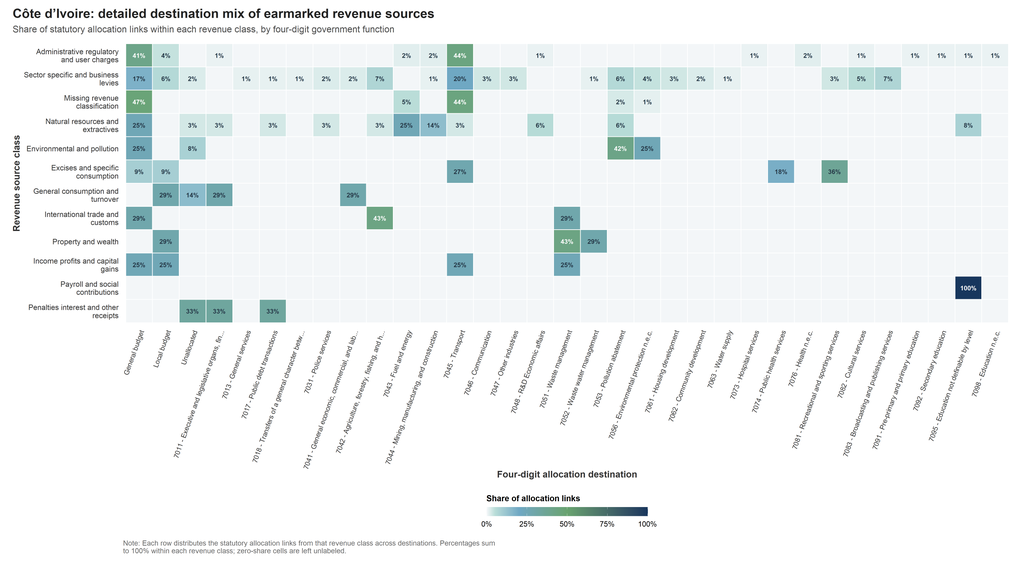

```r
civ_cofog4_share_plot
```

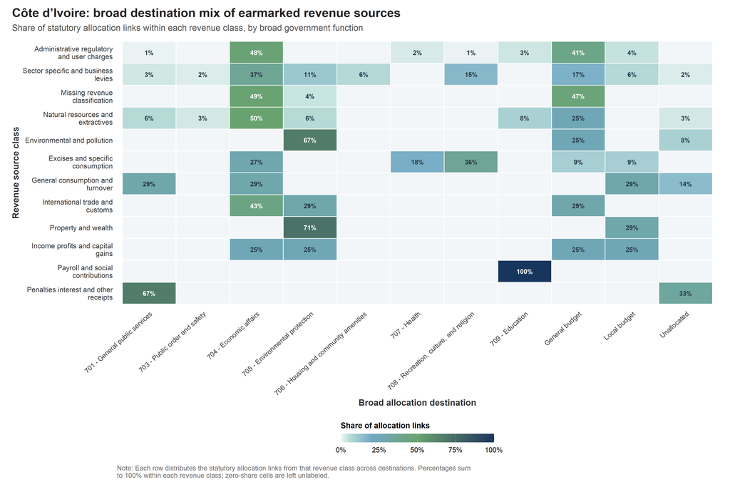

```r
civ_division_share_plot
```

# 5. Cameroon share heatmaps

```r
cmr_cofog4_share_plot <- make_share_heatmap(cmr_cofog4_share_data)
cmr_division_share_plot <- make_share_heatmap(cmr_division_share_data)
```

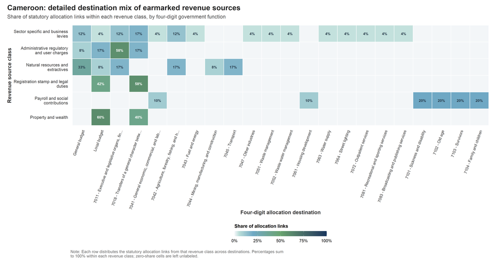

```r
cmr_cofog4_share_plot
```

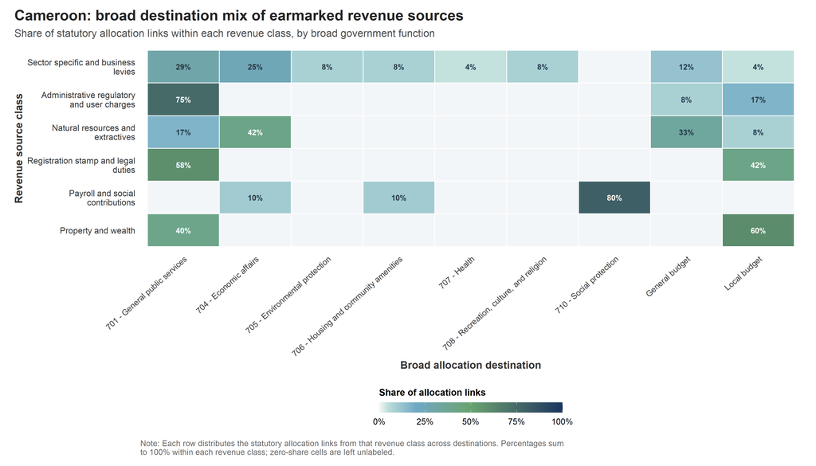

```r
cmr_division_share_plot
```

# 6. Export the four additive PNG/CSV pairs

Only new `10_..._share_heatmap` files are written. No existing country-focus file is included in the output bundle.

```r
output_data <- list(
  "10_civ_revenue_to_cofog4_share_heatmap" =
    civ_cofog4_share_data,
  "10_civ_revenue_to_division_share_heatmap" =
    civ_division_share_data,
  "10_cmr_revenue_to_cofog4_share_heatmap" =
    cmr_cofog4_share_data,
  "10_cmr_revenue_to_division_share_heatmap" =
    cmr_division_share_data
)

output_plots <- list(
  "10_civ_revenue_to_cofog4_share_heatmap" =
    civ_cofog4_share_plot,
  "10_civ_revenue_to_division_share_heatmap" =
    civ_division_share_plot,
  "10_cmr_revenue_to_cofog4_share_heatmap" =
    cmr_cofog4_share_plot,
  "10_cmr_revenue_to_division_share_heatmap" =
    cmr_division_share_plot
)

plot_dimensions <- tribble(
  ~stem, ~width, ~height,
  "10_civ_revenue_to_cofog4_share_heatmap", 20, 11,
  "10_civ_revenue_to_division_share_heatmap", 15, 10,
  "10_cmr_revenue_to_cofog4_share_heatmap", 17, 9,
  "10_cmr_revenue_to_division_share_heatmap", 14, 8
)

csv_output_paths <- set_names(
  file.path(
    country_focus_table_dir,
    paste0(names(output_data), ".csv")
  ),
  names(output_data)
)
png_output_paths <- set_names(
  file.path(
    country_focus_figure_dir,
    paste0(names(output_plots), ".png")
  ),
  names(output_plots)
)

if (any(csv_output_paths %in% count_grid_paths)) {
  stop("A new share output path overlaps an existing count-grid input.")
}

all_output_paths <- c(
  set_names(
    unname(csv_output_paths),
    paste0(names(csv_output_paths), "_csv")
  ),
  set_names(
    unname(png_output_paths),
    paste0(names(png_output_paths), "_png")
  )
)
```

```r
stage_dir <- tempfile(pattern = "10_country_share_stage_")
dir.create(stage_dir, recursive = TRUE, showWarnings = FALSE)

stage_csv_paths <- set_names(
  file.path(stage_dir, paste0(names(output_data), ".csv")),
  names(output_data)
)
stage_png_paths <- set_names(
  file.path(stage_dir, paste0(names(output_plots), ".png")),
  names(output_plots)
)
stage_output_paths <- c(
  set_names(
    unname(stage_csv_paths),
    paste0(names(stage_csv_paths), "_csv")
  ),
  set_names(
    unname(stage_png_paths),
    paste0(names(stage_png_paths), "_png")
  )
)

iwalk(output_data, function(data, stem) {
  write_csv(data, stage_csv_paths[[stem]], na = "")
})

iwalk(output_plots, function(plot_object, stem) {
  dimensions <- plot_dimensions %>%
    filter(.data$stem == .env$stem)

  ggsave(
    filename = stage_png_paths[[stem]],
    plot = plot_object,
    width = dimensions$width,
    height = dimensions$height,
    units = "in",
    dpi = 300,
    bg = "white"
  )
})

same_table_values <- function(saved, expected) {
  if (!identical(names(saved), names(expected)) ||
      nrow(saved) != nrow(expected)) {
    return(FALSE)
  }

  column_checks <- map_lgl(names(expected), function(column_name) {
    expected_values <- expected[[column_name]]
    saved_values <- saved[[column_name]]

    if (is.numeric(expected_values)) {
      isTRUE(all.equal(
        as.numeric(saved_values),
        as.numeric(expected_values),
        tolerance = 1e-12,
        check.attributes = FALSE
      ))
    } else {
      identical(
        as.character(saved_values),
        as.character(expected_values)
      )
    }
  })

  all(column_checks)
}

staged_csv_checks <- imap_dfr(output_data, function(expected, stem) {
  saved <- read_csv(
    stage_csv_paths[[stem]],
    show_col_types = FALSE,
    progress = FALSE
  )

  tibble(
    output = paste0(stem, ".csv"),
    rows = nrow(saved),
    passed = same_table_values(saved, expected)
  )
})

staged_png_checks <- imap_dfr(output_plots, function(plot_object, stem) {
  tibble(
    output = paste0(stem, ".png"),
    bytes = file.info(stage_png_paths[[stem]])$size,
    passed = file.exists(stage_png_paths[[stem]]) &&
      file.info(stage_png_paths[[stem]])$size > 10000
  )
})

if (!all(staged_csv_checks$passed) || !all(staged_png_checks$passed)) {
  print(staged_csv_checks %>% filter(!passed))
  print(staged_png_checks %>% filter(!passed))
  stop("Staged share-heatmap output checks failed; nothing was published.")
}
```

```r
commit_output_bundle <- function(stage_paths, final_paths) {
  existed_before <- set_names(
    file.exists(final_paths),
    names(final_paths)
  )
  backup_dir <- tempfile(pattern = "10_country_share_backup_")
  dir.create(backup_dir, recursive = TRUE, showWarnings = FALSE)
  backup_paths <- file.path(backup_dir, basename(final_paths))
  names(backup_paths) <- names(final_paths)
  committed <- FALSE

  on.exit({
    if (!committed) {
      for (name in names(final_paths)) {
        if (existed_before[[name]] && file.exists(backup_paths[[name]])) {
          file.copy(
            backup_paths[[name]],
            final_paths[[name]],
            overwrite = TRUE
          )
        } else if (!existed_before[[name]] &&
                   file.exists(final_paths[[name]])) {
          file.remove(final_paths[[name]])
        }
      }
    }
    unlink(stage_dir, recursive = TRUE, force = TRUE)
    unlink(backup_dir, recursive = TRUE, force = TRUE)
  }, add = TRUE)

  for (name in names(final_paths)[existed_before]) {
    if (!file.copy(
      final_paths[[name]],
      backup_paths[[name]],
      overwrite = FALSE
    )) {
      stop("Could not create a rollback copy for ", name, ".")
    }
  }

  commit_ok <- vapply(
    names(final_paths),
    function(name) file.copy(
      stage_paths[[name]],
      final_paths[[name]],
      overwrite = TRUE
    ),
    logical(1)
  )

  if (!all(commit_ok)) {
    stop("Could not commit every requested share-heatmap output.")
  }

  final_csv_checks <- imap_dfr(output_data, function(expected, stem) {
    saved <- read_csv(
      csv_output_paths[[stem]],
      show_col_types = FALSE,
      progress = FALSE
    )

    tibble(
      output = paste0(stem, ".csv"),
      rows = nrow(saved),
      passed = same_table_values(saved, expected)
    )
  })

  final_png_checks <- imap_dfr(output_plots, function(plot_object, stem) {
    tibble(
      output = paste0(stem, ".png"),
      bytes = file.info(png_output_paths[[stem]])$size,
      passed = file.exists(png_output_paths[[stem]]) &&
        file.info(png_output_paths[[stem]])$size > 10000
    )
  })

  if (!all(final_csv_checks$passed) || !all(final_png_checks$passed)) {
    print(final_csv_checks %>% filter(!passed))
    print(final_png_checks %>% filter(!passed))
    stop("Final share-heatmap checks failed; restoring prior outputs.")
  }

  committed <- TRUE
  list(csv_checks = final_csv_checks, png_checks = final_png_checks)
}

committed_outputs <- commit_output_bundle(
  stage_output_paths,
  all_output_paths
)

input_md5_after <- unname(tools::md5sum(count_grid_paths))
input_integrity_check <- tibble(
  input = names(count_grid_paths),
  md5_before = input_md5_before,
  md5_after = input_md5_after,
  unchanged = input_md5_before == input_md5_after
)

if (!all(input_integrity_check$unchanged)) {
  print(input_integrity_check)
  stop("An existing count-grid input changed during the additive workflow.")
}
```

```r
display_table(committed_outputs$csv_checks)
```

```
##
##
## |output                                       | rows|passed |
## |:--------------------------------------------|----:|:------|
## |10_civ_revenue_to_cofog4_share_heatmap.csv   |  396|TRUE   |
## |10_civ_revenue_to_division_share_heatmap.csv |  132|TRUE   |
## |10_cmr_revenue_to_cofog4_share_heatmap.csv   |  132|TRUE   |
## |10_cmr_revenue_to_division_share_heatmap.csv |   54|TRUE   |
```

```r
display_table(committed_outputs$png_checks)
```

```
##
##
## |output                                       |  bytes|passed |
## |:--------------------------------------------|------:|:------|
## |10_civ_revenue_to_cofog4_share_heatmap.png   | 445099|TRUE   |
## |10_civ_revenue_to_division_share_heatmap.png | 303423|TRUE   |
## |10_cmr_revenue_to_cofog4_share_heatmap.png   | 300092|TRUE   |
## |10_cmr_revenue_to_division_share_heatmap.png | 216332|TRUE   |
```

```r
display_table(input_integrity_check)
```

```
##
##
## |input        |md5_before                       |md5_after                        |unchanged |
## |:------------|:--------------------------------|:--------------------------------|:---------|
## |civ_cofog4   |1423d40cdf65b5694a4d44a3c896ca09 |1423d40cdf65b5694a4d44a3c896ca09 |TRUE      |
## |civ_division |3b8b6ff8c62389371a79e8df38ada33f |3b8b6ff8c62389371a79e8df38ada33f |TRUE      |
## |cmr_cofog4   |e5ddcc77cab927268c0884fcbe875ed6 |e5ddcc77cab927268c0884fcbe875ed6 |TRUE      |
## |cmr_division |70ad63c9bce6b3a906cfdaccde67cee7 |70ad63c9bce6b3a906cfdaccde67cee7 |TRUE      |
```

# 7. Run summary

```r
cat(
  "- Four additive share heatmaps and four matching CSV files were created.\n",
  "- Countries included: Cote d'Ivoire (CIV) and Cameroon (CMR).\n",
  "- Every revenue-class row sums to 100% within numerical tolerance.\n",
  "- Zero-share cells remain in the complete grids but are not labeled.\n",
  "- Existing Sankeys, count heatmaps, plot-data files, and code were not ",
  "included in the write bundle.\n",
  sep = ""
)
```

- Four additive share heatmaps and four matching CSV files were created.
- Countries included: Cote d’Ivoire (CIV) and Cameroon (CMR).
- Every revenue-class row sums to 100% within numerical tolerance.
- Zero-share cells remain in the complete grids but are not labeled.
- Existing Sankeys, count heatmaps, plot-data files, and code were not included in the write bundle.